# Testing bindSC integration using simulated data

Jinzhuang Dou

July 7, 2020

This guide will demonstrate the usage of bindSC to intergrate RNA and ATAC under the gene regulation modeling with expression level regulated by both proximal and distal peaks.

### Stage 1: load simulation data

User can refer to `sim.R` for the details of simulaiton process (It will take 5 mins).

```r
library(bindSC)
dim(sim$X)
```

```
## [1] 200 150
```

```r
dim(sim$Y)
```

```
## [1] 400 300
```

```r
dim(sim$Z0)
```

```
## [1] 200 300
```

# Usage of BiCCA

```r
?BiCCA
```

In this example, dataset `X` is the gene expression matrix and `Y` is the peak matrix. `Z0` is the simulated gene activity matrix. Seurat, Liger and Harmony use (`X`, `Z0`) as input and BiCCA uses (`X`, `Z0`, `Y`) as input.

bindSC also requires the modality specfic clustering ID `X.clst`,`Y.clst` to test the integraiton performance

The option `tolereance` is usually set from 0.01 to 0.05 to avoid unnecessary iteration when sample size is large.

This step will take ~10s

```r
out <- BiCCA(X=sim$X, Z0=sim$Z0, Y=sim$Y,
      K = 5,
      alpha = 0.1,
      lambda = 0.5,
      X.clst = sim$X_meta$Group,
      Y.clst = sim$Y_meta$Group,
      num.iteration = 100,
      temp.path = "./out",
      tolerance = 0.01,
      save = TRUE,
      block.size =10000)
```

```
## 2022-09-28 07:40:11  Started!
```

```
## 2022-09-28 07:40:11  Dimension Check: X[200x150] Y[400x300] Z0[200x300]
```

```
## 2022-09-28 07:40:11  Decomposing started!
```

```
## 2022-09-28 07:40:12  Done! The decomposition is converged.
```

Show the iteration index `delta`

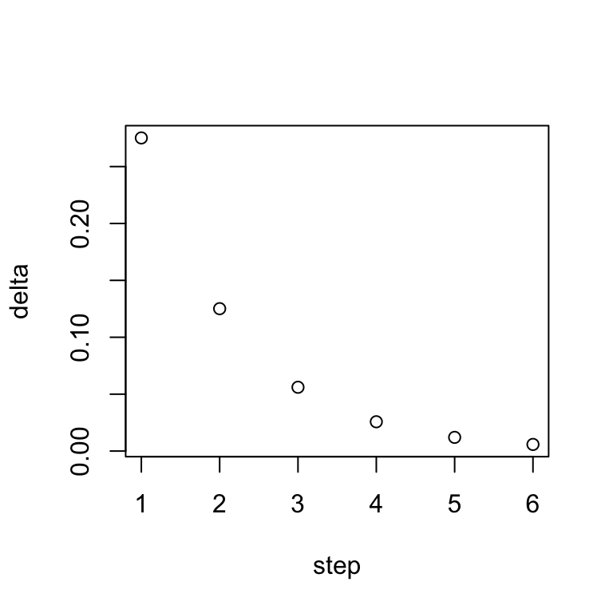

```r
plot(out$delta, xlab="step", ylab="delta")
```

```r
summary(out)
```

```
##          Length Class  Mode
## u          750  -none- numeric
## r         1500  -none- numeric
## d            5  -none- numeric
## s         1000  -none- numeric
## v         2000  -none- numeric
## Z_est    60000  -none- numeric
## cost_l       6  -none- numeric
## cost_r       6  -none- numeric
## cost_z0      6  -none- numeric
## cost_all     6  -none- numeric
## delta        6  -none- numeric
## score        0  -none- NULL
```

```r
dim(out$u)
```

```
## [1] 150   5
```

```r
dim(out$r)
```

```
## [1] 300   5
```

```r
dim(out$Z_est)
```

```
## [1] 200 300
```

### Stage 2: Comparsion between bindSC and the traditional CCA

# Coembedings from bindSC results

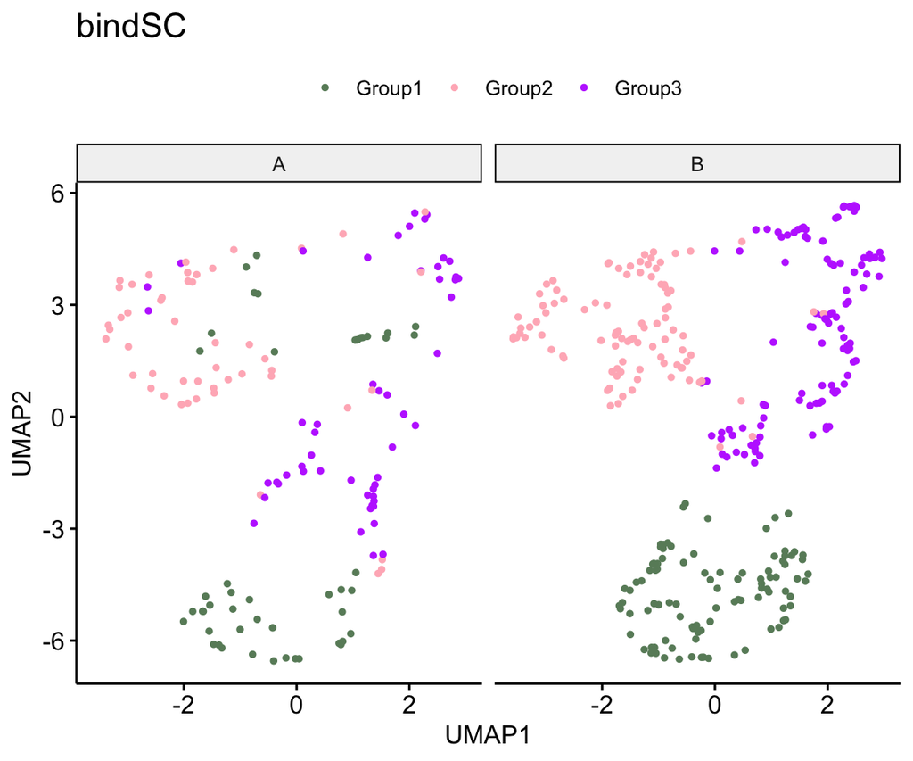

```r
cell_type <- c(sim$X_meta$Group, sim$Y_meta$Group)
data_type <- c(rep("A", dim(out$u)[1]), rep("B",dim(out$r)[1]))
bindsc_umap <- umap(rbind(out$u, out$r))
plt_dt <- data.frame("UMAP1"=bindsc_umap$layout[,1],
                     "UMAP2"=bindsc_umap$layout[,2],
                     "cell_type"= as.factor(cell_type),
                     "data_type"=data_type)
p<-ggscatter(plt_dt, x = "UMAP1", y = "UMAP2",
     color = "cell_type", palette = c("darkseagreen4","lightpink","darkorchid1"),
     repel = FALSE,size=1, alpha=1,legend.title = "", title="bindSC", font.title=16) + facet_grid(~data_type)
p
```

# Performance on traditional CCA method (results are from the first iteration).

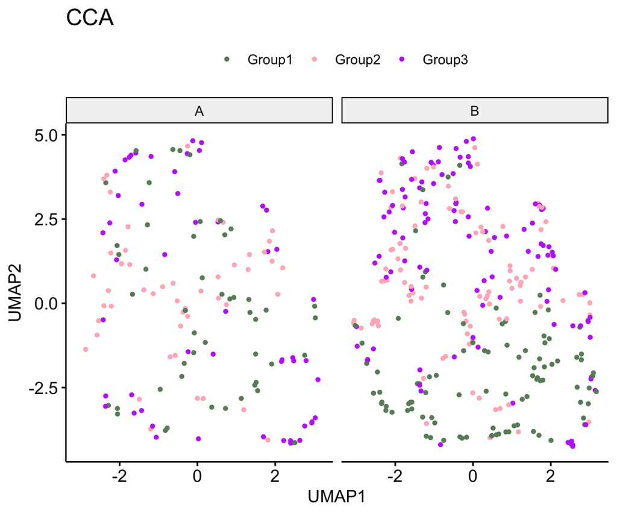

```r
out <- readRDS(file="./out/iteration1.rds")
cca_umap <- umap(rbind(out$u, out$r))
plt_dt <- data.frame("UMAP1"=cca_umap$layout[,1],
                     "UMAP2"=cca_umap$layout[,2],
                     "cell_type"= as.factor(cell_type),
                     "data_type"=data_type)
# remove some outliers from CCA
p<-ggscatter(plt_dt[(plt_dt$UMAP1>(-20) & plt_dt$UMAP2<20), ], x = "UMAP1", y = "UMAP2",
     color = "cell_type", palette = c("darkseagreen4","lightpink","darkorchid1"),
     repel = FALSE,size=1, alpha=1,legend.title = "", title="CCA", font.title=16) + facet_grid(~data_type)
p
```